# Mouse Olfactory Analysis

Zhaorong Li

Jan/13/2022

# 1 MERFISH Image visualization

This dataset [1] is downloaded from https://zenodo.org/record/5745947#.YeB7VtHMKUk (Set 1). The Watershed segmentation is used in the analysis.

## 1.1 Transcriptome Analysis

In this case the authors do not provide cell type assignment. So we need to use the data to generate cell type.

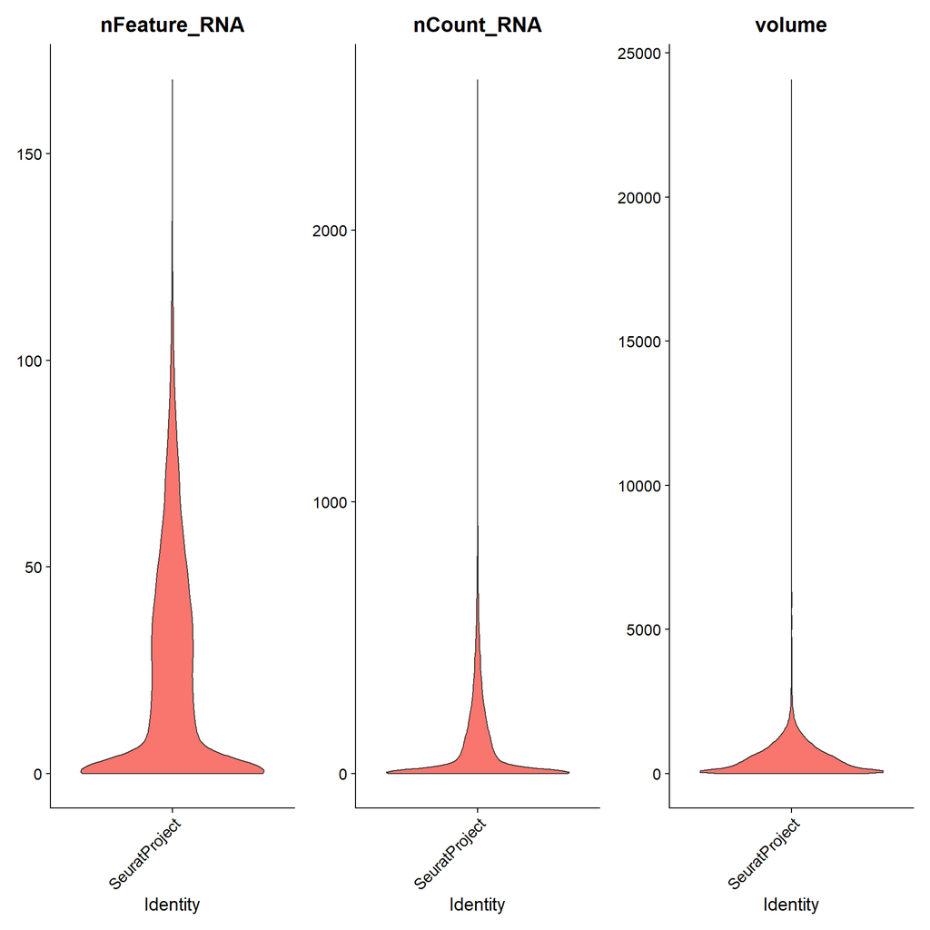

```r
Count.matrix=read.csv('barcodes_per_feature.csv.gz',header = T,row.names =1,check.names = F)
Count.matrix=t(as.matrix(Count.matrix))
meta.data=read.csv('feature_metadata.csv.gz',header = T,row.names = 1,check.names = F)
Count.matrix=Count.matrix[!grepl('Blank',rownames(Count.matrix)),]
Seurat_Object=CreateSeuratObject(Count.matrix,meta.data=meta.data)

VlnPlot(Seurat_Object,c('nFeature_RNA','nCount_RNA','volume'),pt.size = 0)
```

```r
Seurat_Object=subset(Seurat_Object,subset=nFeature_RNA>15&nFeature_RNA<100)

Seurat_Object=NormalizeData(Seurat_Object)
Seurat_Object=FindVariableFeatures(Seurat_Object)
Seurat_Object=ScaleData(Seurat_Object)
Seurat_Object=RunPCA(Seurat_Object,npcs = 50)
```

```
## PC_ 1
## Positive:  Atp1b1, Faim2, Nsg1, Hsp90aa1, Rab6b, Calm2, Mmp16, Hdac11, Pcdhgc4, Penk
##     Pcdhgc5, Olfr418, Mycbp2, Dpysl2, Ndfip1, Olfr1564, Mdga2, Sox11, Pcdha12, Pcdhga11
##     Pcdhac2, Olfr1427, Cep250, Olfr1197, Cd47, Scgn, Olfr332, Pcdhga3, Pcdhb6, Olfr1259
## Negative:  Ptn, Omp, Glul, Cd55, Kctd12, Anxa5, Prom1, Pcdhgc3, Olfr1271, Lifr
##     Olfr1219, Gldc, Olfr417, Olfr129, Itm2b, Olfr190, Olfr131, Olfr524, Olfr32, Olfr1124
##     Olfr76, Olfr414, Olfr1295, Olfr1428, Olfr124, Olfr136, Hist2h2be, Olfr1318, Olfr1252, Olfr24
## PC_ 2
## Positive:  Ptn, Kctd12, Pcdhgc3, Omp, Cd55, Glul, Lifr, Anxa5, Olfr32, Hist2h2be
##     Rnd2, Cotl1, Kif5b, Olfr1271, Inpp5f, Olfr1219, Prnp, Olfr417, Olfr190, Gldc
##     Olfr195, Prom1, Gramd1c, Itm2b, Pcdhga10, Olfr1352, Pcdhgb4, Cep250, Uchl1, Pcdhgb6
## Negative:  Atp1b1, Calm2, Penk, Rab6b, Hsp90aa1, Nsg1, Dpysl2, Faim2, Pcdhgc5, Olfr1564
##     Sox11, Mmp16, Scgn, Hdac11, Pcdha12, Ndfip1, Mycbp2, Olfr60, Olfr364-ps1, Olfr1336
##     Calb2, Olfr859, Pcdha9, Olfr362, Pcdha8, Olfr136, Olfr314, Olfr332, Olfr1437, Olfr1211
## PC_ 3
## Positive:  Penk, Ncam2, Itm2b, Olfr1564, Pcdhgc5, Sox11, Kctd12, Pcdhga10, Mmp16, Cd55
##     Hist2h2be, Olfr549, Olfr1206, Olfr171, Olfr1219, Pcdhb20, Olfr1271, Olfr32, Olfr267, Pcdhga11
##     Olfr212, Olfr1205, Pcdhga3, Olfr1381, Rhoq, Olfr1259, Pcdhgb7, Nsg1, Pcdhgb5, Pcdhgb2
## Negative:  Cdhr1, Gap43, Uchl1, Calb2, Olfr533, Gldc, Dpysl2, Faim2, Glul, Hdac11
##     Sorbs2, Anxa5, Cadps2, Rab6b, Olfr455, Prnp, Hsp90aa1, Olfr1197, Pcdhgc3, Olfr536
##     Olfr706, Olfr1247, Pcdhac2, Ndfip1, Cfap52, Olfr1100, Prom1, Olfr187, Pcdhb6, Cotl1
## PC_ 4
## Positive:  Olfr533, Olfr1197, Cd55, Olfr455, Olfr32, Cdhr1, Olfr1100, Olfr536, Olfr1271, Olfr1349
##     Olfr706, Olfr1263, Olfr531, Olfr418, Olfr187, Olfr788, Olfr1030, Pcdhb6, Olfr1312, Olfr1247
##     Ncam2, Olfr1229, Olfr479, Olfr1412, Olfr810, Olfr523, Olfr332, Olfr1219, Olfr122, Olfr713
## Negative:  Gldc, Rhoq, Glul, Pcdhgc3, Prom1, Dpysl2, Cadps2, Sorbs2, Sox11, Cotl1
##     Calb2, Prnp, Rnd2, Ndfip1, Pcdhgb4, Mmp16, Pcdhga6, Rab6b, Usp21, Pcdhgc5
##     Pcdhga11, Hdac11, Pcdhgb7, Pcdhga4, Anxa5, Ptn, Nrp2, Scgn, Pcdha11, Pcdhac2
## PC_ 5
## Positive:  Calb2, Scgn, Cd47, Sorbs2, Olfr32, Omp, Olfr1271, Cd55, Pcdhac2, Pcdhgc4
##     Inpp5f, Atp1b1, Cfap52, Nsg1, Hdac11, Ndfip1, Olfr1243, Olfr1219, Kctd12, Olfr129
##     Olfr417, Pcdhga8, Olfr1463, Pcdhgb5, Olfr1352, Pcdha11, Olfr290, Olfr730, Olfr524, Pcdha8
## Negative:  Gldc, Itm2b, Prom1, Rhoq, Penk, Lifr, Anxa5, Olfr190, Sox11, Olfr1197
##     Prnp, Pcdhgc5, Glul, Olfr1259, Olfr455, Olfr187, Calm2, Olfr15, Sytl2, Olfr1030
##     Nrp2, Cotl1, Rnd2, Olfr1205, Olfr212, Olfr1412, Olfr1564, Pcdhga6, Olfr330, Olfr1100
```

```r
Seurat_Object=RunUMAP(Seurat_Object,dims = 1:20)
Seurat_Object=FindNeighbors(Seurat_Object,dims = 1:20)
Seurat_Object=FindClusters(Seurat_Object,resolution = 0.5,algorithm = 2)
```

```
## Modularity Optimizer version 1.3.0 by Ludo Waltman and Nees Jan van Eck
##
## Number of nodes: 16026
## Number of edges: 451607
##
## Running Louvain algorithm with multilevel refinement...
## Maximum modularity in 10 random starts: 0.8317
## Number of communities: 10
## Elapsed time: 1 seconds
```

```r
Seurat_Object.markers=FindAllMarkers(Seurat_Object,only.pos = T)
```

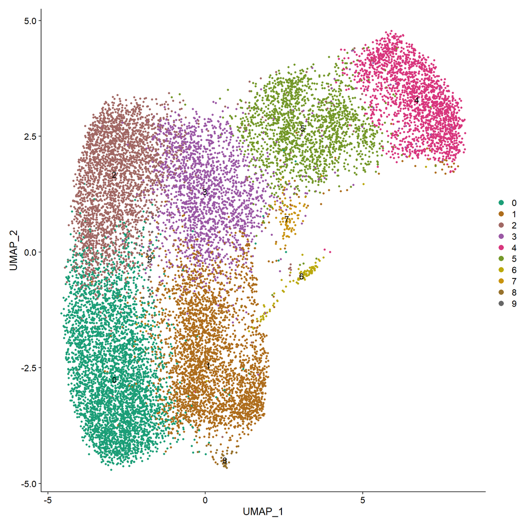

```r
getPalette = colorRampPalette(brewer.pal(8, "Dark2"))


color=getPalette(length(unique(Seurat_Object@meta.data$seurat_clusters)))

DimPlot(Seurat_Object,cols = color,label = T,pt.size = 1)
```

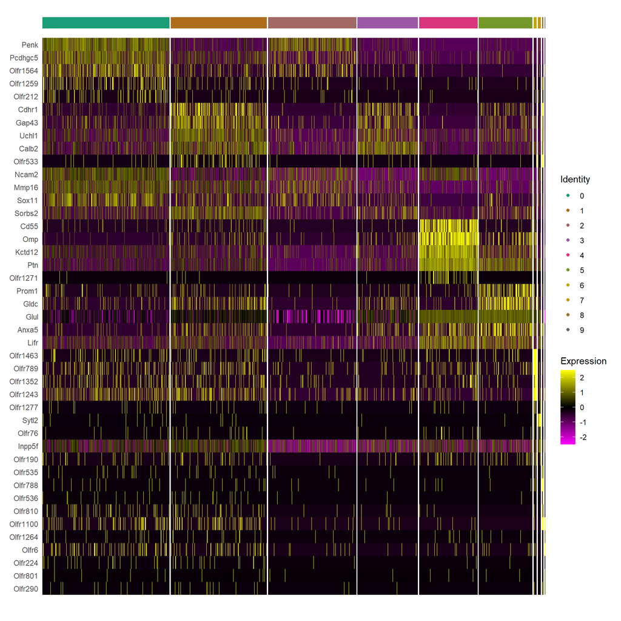

```r
Seurat_Object.markers %>%
    group_by(cluster) %>%
    top_n(n = 5, wt = avg_log2FC) -> top10
DoHeatmap(Seurat_Object, features = top10$gene,group.colors = color,label = F)
```

```r
Cell_spacial_information=data.frame(cell=rownames(Seurat_Object@meta.data),
                                    x=Seurat_Object@meta.data$center_x,
                                    y=Seurat_Object@meta.data$center_y,
                                    Celltype=Seurat_Object@meta.data$seurat_clusters)
```

## 1.2 Plot Cell by centroid Coordinates

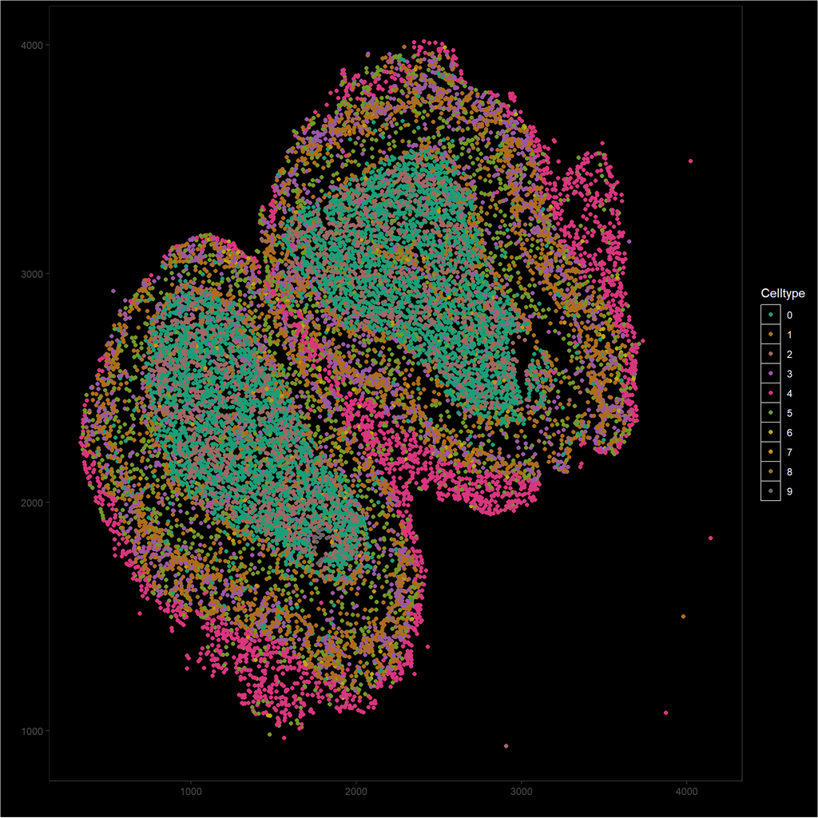

```r
ggplot(Cell_spacial_information,aes(x=x,y=y,colour=Celltype))+geom_point()+
  xlim(min(Cell_spacial_information$x),max(Cell_spacial_information$x))+
  ylim(min(Cell_spacial_information$y),max(Cell_spacial_information$y)) + scale_color_manual(values = color)+ theme_bw() +
  theme(
    # get rid of panel grids
    panel.grid.major = element_blank(),
    panel.grid.minor = element_blank(),
    # Change plot and panel background
    plot.background=element_rect(fill = "black"),
    panel.background = element_rect(fill = 'black'),
    # Change legend
    #legend.position = c(0.6, 0.07),
    #legend.direction = "horizontal",
    legend.background = element_rect(fill = "black", color = NA),
    legend.key = element_rect(color = "gray", fill = "black"),
    legend.title = element_text(color = "white"),
    legend.text = element_text(color = "white")
  )
```

# 2 Analysis

## 2.1 Area Calculator Function

In this case instead of calculating the area overlap between cells and fragments, the number of cells are calculated using the coordinates of the cells.

```r
source('functions.R')
```

```r
Area.50.50=Area_Counter(min(Cell_spacial_information$x),
                        max(Cell_spacial_information$x),
                        min(Cell_spacial_information$y),
                        max(Cell_spacial_information$y),numbers = 50,cell_coordinates = Cell_spacial_information)





reactable(Area.50.50)
```

|  | 4 | 1 | 0 | 3 | 5 | 2 | 7 | 6 | 8 | 9 |
| --- | --- | --- | --- | --- | --- | --- | --- | --- | --- | --- |
| 332.351648364216,408.587855031565,2043.31957758859,2104.93403324395 | 1 | 0 | 0 | 0 | 2 | 0 | 0 | 0 | 0 | 0 |
| 332.351648364216,408.587855031565,2104.93403324395,2166.54848889932 | 8 | 0 | 0 | 0 | 0 | 0 | 0 | 0 | 0 | 0 |
| 332.351648364216,408.587855031565,2166.54848889932,2228.16294455469 | 6 | 1 | 0 | 0 | 0 | 0 | 0 | 0 | 0 | 0 |
| 332.351648364216,408.587855031565,2228.16294455469,2289.77740021005 | 5 | 2 | 0 | 3 | 1 | 0 | 0 | 0 | 0 | 0 |
| 332.351648364216,408.587855031565,2289.77740021005,2351.39185586542 | 2 | 2 | 0 | 3 | 2 | 1 | 0 | 0 | 0 | 0 |
| 332.351648364216,408.587855031565,2351.39185586542,2413.00631152078 | 2 | 0 | 0 | 3 | 3 | 1 | 0 | 1 | 0 | 0 |
| 332.351648364216,408.587855031565,2413.00631152078,2474.62076717615 | 2 | 1 | 0 | 0 | 1 | 0 | 0 | 0 | 0 | 0 |
| 332.351648364216,408.587855031565,2474.62076717615,2536.23522283152 | 0 | 1 | 0 | 1 | 0 | 1 | 0 | 0 | 0 | 0 |
| 408.587855031565,484.824061698914,1920.09066627785,1981.70512193322 | 0 | 0 | 0 | 0 | 4 | 0 | 0 | 0 | 0 | 0 |
| 408.587855031565,484.824061698914,1981.70512193322,2043.31957758859 | 9 | 0 | 0 | 0 | 0 | 0 | 0 | 0 | 0 | 0 |

[output cut: 1346 more lines]

## 2.2 Normalization and Scaling

The cell composition of each fragment is scaled by the total number of cells in the fragment. The scaled number is multiplied by 1,000,000 and then log transformed.

Basically it is log transformed CPM normalized. This step is included in the Area_Cluster() function.

```r
Area.50.50.normalized=Area.50.50/rowSums(Area.50.50)
Area.50.50.normalized=Area.50.50.normalized*(1e6)
Area.50.50.normalized=log(Area.50.50.normalized+1)

reactable(Area.50.50.normalized)
```

|  | 4 | 1 | 0 | 3 | 5 | 2 | 7 | 6 | 8 | 9 |
| --- | --- | --- | --- | --- | --- | --- | --- | --- | --- | --- |
| 332.351648364216,408.587855031565,2043.31957758859,2104.93403324395 | 12.7169012692917 | 0 | 0 | 0 | 13.410046949855 | 0 | 0 | 0 | 0 | 0 |
| 332.351648364216,408.587855031565,2104.93403324395,2166.54848889932 | 13.8155115579638 | 0 | 0 | 0 | 0 | 0 | 0 | 0 | 0 | 0 |
| 332.351648364216,408.587855031565,2166.54848889932,2228.16294455469 | 13.661361044803 | 11.8696074088845 | 0 | 0 | 0 | 0 | 0 | 0 | 0 | 0 |
| 332.351648364216,408.587855031565,2228.16294455469,2289.77740021005 | 13.0270553975976 | 12.1107679657107 | 0 | 12.516231240494 | 11.4176262851054 | 0 | 0 | 0 | 0 | 0 |
| 332.351648364216,408.587855031565,2289.77740021005,2351.39185586542 | 12.2060776455177 | 12.2060776455177 | 0 | 12.6115410869661 | 12.2060776455177 | 11.5129354649202 | 0 | 0 | 0 | 0 |
| 332.351648364216,408.587855031565,2351.39185586542,2413.00631152078 | 12.2060776455177 | 0 | 0 | 12.6115410869661 | 12.6115410869661 | 11.5129354649202 | 0 | 11.5129354649202 | 0 | 0 |
| 332.351648364216,408.587855031565,2413.00631152078,2474.62076717615 | 13.1223653774023 | 12.4292201968364 | 0 | 0 | 12.4292201968364 | 0 | 0 | 0 | 0 | 0 |
| 332.351648364216,408.587855031565,2474.62076717615,2536.23522283152 | 0 | 12.7169012692917 | 0 | 12.7169012692917 | 0 | 12.7169012692917 | 0 | 0 | 0 | 0 |
| 408.587855031565,484.824061698914,1920.09066627785,1981.70512193322 | 0 | 0 | 0 | 0 | 13.8155115579638 | 0 | 0 | 0 | 0 | 0 |
| 408.587855031565,484.824061698914,1981.70512193322,2043.31957758859 | 13.8155115579638 | 0 | 0 | 0 | 0 | 0 | 0 | 0 | 0 | 0 |

[output cut: 1346 more lines]

## 2.3 Clustering

In this case I used the Louvain Community Clustering Algorithm from igraph package to cluster the area.

```r
clusterlouvain <- Area_Cluster(Area.50.50,ScaleFactor = 1e6,0.5)
```